# Practical Machine Learning Course Project

Jonathan Di Cosmo

23/06/2020

## Overview

The objective of this project is to predict whether barbell lifts are correctly performed and, when they are not, the type of error. The data consist of measurements from sensors on the belt, forearm, arm, and dumbell of 6 participants. They were asked to perform barbell lifts correctly and incorrectly in 4 different ways. The data comes from this source:

Velloso, E.; Bulling, A.; Gellersen, H.; Ugulino, W.; Fuks, H. **Qualitative Activity Recognition of Weight Lifting Exercises**. Proceedings of 4th International Conference in Cooperation with SIGCHI (Augmented Human ’13) . Stuttgart, Germany: ACM SIGCHI, 2013.

Read more: http://groupware.les.inf.puc-rio.br/har.

From the machine learning perspective, the project is a supervised classification problem and can be tackled by a wide set of methods. We have found that random forests achieve a high accuracy.

## Data preparation

The following commands load the data and print a useful summary:

```r
raw_data <- read.csv('pml-training.csv', na.strings = c('NA', '', '#DIV/0!'))
str(raw_data)
```

```
## 'data.frame':    19622 obs. of  160 variables:
##  $ X                       : int  1 2 3 4 5 6 7 8 9 10 ...
##  $ user_name               : Factor w/ 6 levels "adelmo","carlitos",..: 2 2 2 2 2 2 2 2 2 2 ...
##  $ raw_timestamp_part_1    : int  1323084231 1323084231 1323084231 1323084232 1323084232 1323084232 1323084232 1323084232 1323084232 1323084232 ...
##  $ raw_timestamp_part_2    : int  788290 808298 820366 120339 196328 304277 368296 440390 484323 484434 ...
##  $ cvtd_timestamp          : Factor w/ 20 levels "02/12/2011 13:32",..: 9 9 9 9 9 9 9 9 9 9 ...
##  $ new_window              : Factor w/ 2 levels "no","yes": 1 1 1 1 1 1 1 1 1 1 ...
##  $ num_window              : int  11 11 11 12 12 12 12 12 12 12 ...
##  $ roll_belt               : num  1.41 1.41 1.42 1.48 1.48 1.45 1.42 1.42 1.43 1.45 ...
##  $ pitch_belt              : num  8.07 8.07 8.07 8.05 8.07 8.06 8.09 8.13 8.16 8.17 ...
##  $ yaw_belt                : num  -94.4 -94.4 -94.4 -94.4 -94.4 -94.4 -94.4 -94.4 -94.4 -94.4 ...
##  $ total_accel_belt        : int  3 3 3 3 3 3 3 3 3 3 ...
##  $ kurtosis_roll_belt      : num  NA NA NA NA NA NA NA NA NA NA ...
##  $ kurtosis_picth_belt     : num  NA NA NA NA NA NA NA NA NA NA ...
##  $ kurtosis_yaw_belt       : logi  NA NA NA NA NA NA ...
```

[output cut: 86 more lines]

We see that the first variable (X) is an index and can be deleted. Moreover, many variables have missing values. We can inspect how many missing values there are with a command like `colSums(is.na(raw_data))`. We decide to delete all the variables that have more than 75% of missing values:

```r
raw_data <- raw_data[, -1]
raw_data <- raw_data[, colMeans(is.na(raw_data)) <= 0.75]
```

We can also remove variables that have zero or near zero variance:

```r
library(caret)
raw_data <- raw_data[, -nearZeroVar(raw_data)]
```

After this cleaning, the number of observations and variables are respectively:

```r
dim(raw_data)
```

```
## [1] 19622    58
```

Finally, we split the dataset between a training and a testing set:

```r
set.seed(42)
inTrain = createDataPartition(raw_data$classe, p = 0.7, list = FALSE)
training = raw_data[inTrain,]
testing = raw_data[-inTrain,]
```

## Data exploration

First, we check that the classes are rougly balanced:

```r
table(raw_data$class)
```

```
##
##    A    B    C    D    E
## 5580 3797 3422 3216 3607
```

Then it is useful to visualize the correlations between the variables. The next plot shows that there are not too many highly correlated variables.

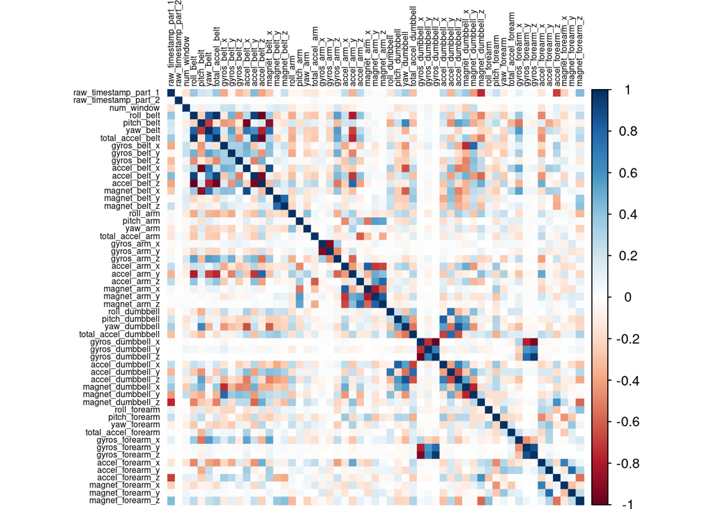

```r
library(corrplot)
corrplot(cor(Filter(is.numeric, training)), method = "color", tl.cex = 0.5, tl.col = "black")
```

## Fitting a random forest

Random forests are usually a good first choice because they are simple to use (they don’t require a lot of preprocessing, like normalization) and they are not too prone to overfitting. Another advantage of random forests is the possibility to estimate the features importance (which is outside the scope of this project). The next command fits a random forest to the training data using the caret package. We use 3-fold cross-validation as resampling method because it is faster than the bootstrapping technique.

```r
ctrl <- trainControl(method = "cv", number = 3)
mdl <- train(classe ~ ., data = training, method = "rf", trControl = ctrl)
mdl
```

```
## Random Forest
##
## 13737 samples
##    57 predictor
##     5 classes: 'A', 'B', 'C', 'D', 'E'
##
## No pre-processing
## Resampling: Cross-Validated (3 fold)
## Summary of sample sizes: 9157, 9157, 9160
## Resampling results across tuning parameters:
##
##   mtry  Accuracy   Kappa
##    2    0.9855140  0.9816708
##   40    0.9986169  0.9982505
##   79    0.9985441  0.9981584
##
## Accuracy was used to select the optimal model using the largest value.
## The final value used for the model was mtry = 40.
```

Now we compute the predictions on the test set:

```r
confusionMatrix(testing$classe, predict(mdl, newdata = testing))
```

```
## Confusion Matrix and Statistics
##
##           Reference
## Prediction    A    B    C    D    E
##          A 1674    0    0    0    0
##          B    0 1139    0    0    0
##          C    0    2 1021    3    0
##          D    0    0    0  963    1
##          E    0    0    0    0 1082
##
## Overall Statistics
##
##                Accuracy : 0.999
##                  95% CI : (0.9978, 0.9996)
##     No Information Rate : 0.2845
##     P-Value [Acc > NIR] : < 2.2e-16
##
##                   Kappa : 0.9987
##
##  Mcnemar's Test P-Value : NA
##
## Statistics by Class:
##
##                      Class: A Class: B Class: C Class: D Class: E
## Sensitivity            1.0000   0.9982   1.0000   0.9969   0.9991
## Specificity            1.0000   1.0000   0.9990   0.9998   1.0000
## Pos Pred Value         1.0000   1.0000   0.9951   0.9990   1.0000
## Neg Pred Value         1.0000   0.9996   1.0000   0.9994   0.9998
## Prevalence             0.2845   0.1939   0.1735   0.1641   0.1840
## Detection Rate         0.2845   0.1935   0.1735   0.1636   0.1839
## Detection Prevalence   0.2845   0.1935   0.1743   0.1638   0.1839
## Balanced Accuracy      1.0000   0.9991   0.9995   0.9983   0.9995
```

Since the accuracy on the test set is very high (0.999), there is no need to try other models.

## Predictions on new data

We now load the test data and perform the predictions:

```r
new_data <- read.csv('pml-testing.csv', na.strings = c('NA', '', '#DIV/0!'))
predict(mdl, newdata = new_data)
```

```
##  [1] B A B A A E D B A A B C B A E E A B B B
## Levels: A B C D E
```

These predictions will be submitted for the automated grading.